# Stool di vita - report iniziale

Amedeo Gagliardi, Antonio Francavilla, Beatrice Piaggeschi

24/6/2020

Last compiled on 30 luglio, 2020

Introduction

MicroRNAs are a class of small non-coding RNAs widely studied as potential biomarkers of different diseases and conditions. Indeed, they represent optimal biomarkers for several reasons including their stability and detectability in different body fluids types. However, fewer studies investigated their expression according to covariates such as gender, age or smoke and alcohol consumption.

Aim of this work was to investigate microRNA expression levels in healthy subjects in relation to age, sex, Body Mass Index (BMI), smoke, alcohol consumption and physical activity.

For this purpose, we analyzed Small RNA-seq data from 233 stool samples of healthy subjects and ran differential expression analyses using DESeq2 package for R software.

Samples were healthy subjects from three different studies: Celiac (n= 35), CRC (n= 76) and VOV (n= 122).

The table below describe the population used in this study

|  | Female (N=133) | Male (N=100) | Overall (N=233) |
| --- | --- | --- | --- |
| Age |  |  |  |
| Mean (SD) | 44.8 (14.6) | 45.6 (14.5) | 45.1 (14.5) |
| Median [Min, Max] | 45.0 [18.0, 80.0] | 46.0 [21.0, 81.0] | 45.0 [18.0, 81.0] |
| BMI |  |  |  |
| Normal | 85 (63.9%) | 57 (57.0%) | 142 (60.9%) |
| Underweight | 16 (12.0%) | 2 (2.0%) | 18 (7.7%) |
| Overweight | 21 (15.8%) | 26 (26.0%) | 47 (20.2%) |
| Obese | 7 (5.3%) | 9 (9.0%) | 16 (6.9%) |
| Missing | 4 (3.0%) | 6 (6.0%) | 10 (4.3%) |
| Smoke |  |  |  |
| Non Smoker | 74 (55.6%) | 43 (43.0%) | 117 (50.2%) |
| Ex Smoker | 33 (24.8%) | 38 (38.0%) | 71 (30.5%) |
| Smoker | 26 (19.5%) | 17 (17.0%) | 43 (18.5%) |
| Missing | 0 (0%) | 2 (2.0%) | 2 (0.9%) |
| Alcohol |  |  |  |
| Abstemious | 14 (10.5%) | 5 (5.0%) | 19 (8.2%) |
| Light drinker | 55 (41.4%) | 27 (27.0%) | 82 (35.2%) |
| Habitual drinker | 26 (19.5%) | 13 (13.0%) | 39 (16.7%) |
| Heavy drinker | 19 (14.3%) | 18 (18.0%) | 37 (15.9%) |
| Over | 19 (14.3%) | 37 (37.0%) | 56 (24.0%) |
| Study |  |  |  |
| CRC | 38 (28.6%) | 38 (38.0%) | 76 (32.6%) |
| VOV | 72 (54.1%) | 50 (50.0%) | 122 (52.4%) |
| Celiac | 23 (17.3%) | 12 (12.0%) | 35 (15.0%) |

# PCA Analyses

## Study

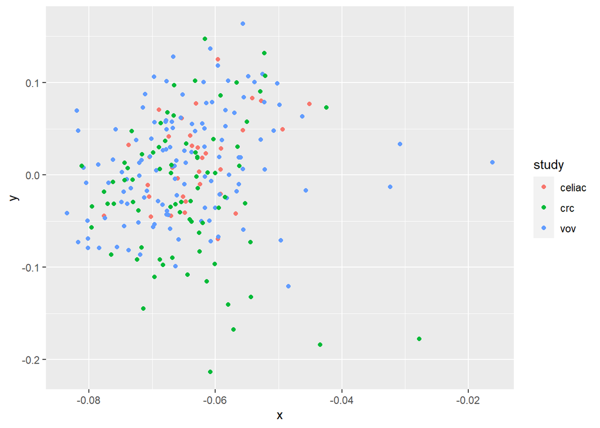

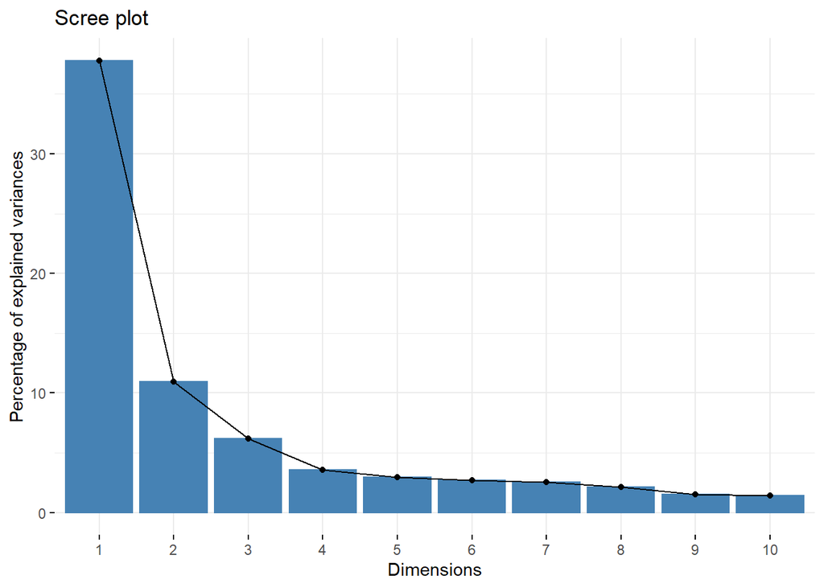

## Library

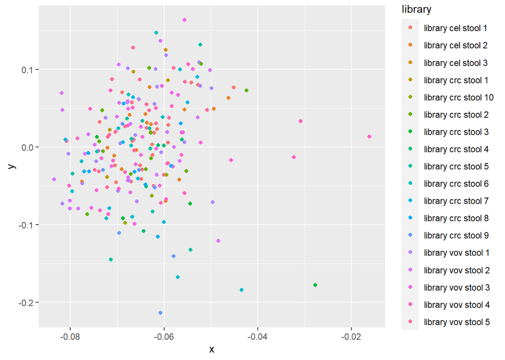

## Pathology

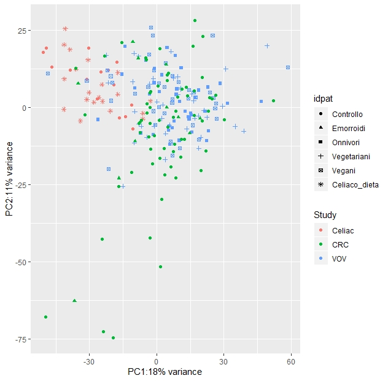

```r
knitr::include_graphics("C:/Users/amedeo/Desktop/R_Projects/sdv/images/pca_study_pat.jpeg")
```

## Repetead samples

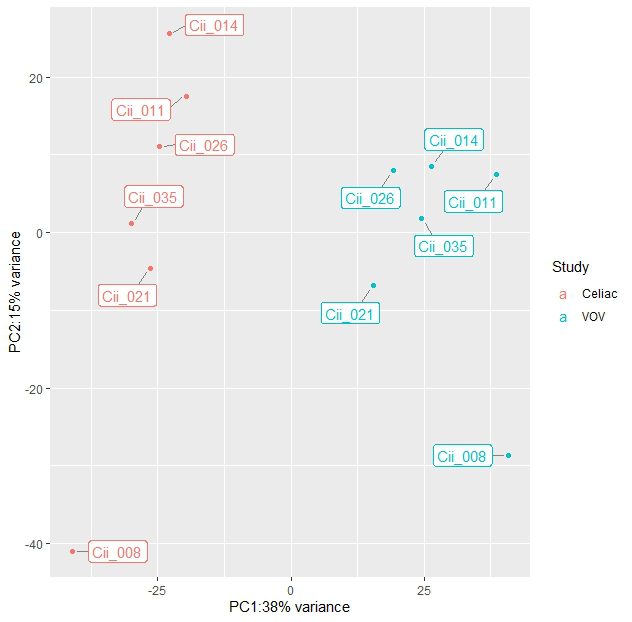

# miRNA count matrix

Data from the sequencing were processed according to our pipeline (Ferrero et al.) and a count matrix including the miRNA mapped reads was obtained for the differential analyses. The resulting matrix was composed of 3524 miRNA. We have filtered this count matrix in order to discard poorly expressed miRNA across the samples. We kept all the miRNA that presented a median of 20 across the samples. After the filtering the matrix included 152 miRNA.

# miRNA differential expression analyses.

We designed several models for DE analyses:

1 - Smoke: ~age + sex + smoke. Age and sex used as adjustment variables. Smoke was coded as non-smoker (0), ex-smoker (1) and smoker (2). 2 – N. cigarettes/day : ~age + sex + N. cigarettes/day. The smokers category was further stratified according to the number of cigarettes per day in light smoker (<16 cigarettes/day) and heavy smokers (>=16 cigarettes/day)

3 - BMI: ~age + sex + bmi. Age and sex used as adjustment variables. BMI was coded as normal weight (0), underweight (1), overweight (2) and obese (3).

6 - Physical activity: ~age + sex + physact. Still in development.

## Smoke

| gene | baseMean | estimate | p.value | p.adjusted | comparison |
| --- | --- | --- | --- | --- | --- |
| hsa-miR-200b-3p | 118.37 | 3.9005 | 0.0000 | 0.0000 | 2_0 |
| hsa-miR-192-5p | 710.88 | 4.0644 | 0.0000 | 0.0000 | 2_0 |
| hsa-let-7a-3p | 507.11 | 4.5899 | 0.0000 | 0.0000 | 2_0 |
| hsa-miR-7113-5p | 259.41 | 2.6152 | 0.0000 | 0.0000 | 2_0 |
| hsa-miR-21-5p | 211.11 | 2.8371 | 0.0000 | 0.0000 | 2_0 |
| hsa-miR-194-3p | 100.90 | 2.3774 | 0.0000 | 0.0000 | 2_0 |
| hsa-miR-4516-3p:Novel | 156.53 | 1.9446 | 0.0000 | 0.0000 | 2_0 |
| hsa-miR-137-3p | 68.98 | 1.9874 | 0.0000 | 0.0000 | 2_0 |
| hsa-miR-4632-5p | 62.16 | 1.6368 | 0.0000 | 0.0000 | 2_0 |
| hsa-miR-1290-5p:Novel | 116.32 | 1.9907 | 0.0000 | 0.0000 | 2_0 |
| hsa-miR-6728-5p | 268.07 | -1.4923 | 0.0000 | 0.0000 | 1_0 |
| hsa-miR-8080 | 43.29 | 1.2956 | 0.0000 | 0.0000 | 2_0 |
| hsa-miR-219a-5p | 44.21 | 1.4666 | 0.0000 | 0.0000 | 2_0 |
| hsa-miR-7704-3p:Novel | 47.40 | 1.2156 | 0.0000 | 0.0000 | 2_0 |
| hsa-miR-4508-3p:Novel | 112.74 | 1.5669 | 0.0000 | 0.0000 | 2_0 |
| hsa-miR-4488-3p:Novel | 174.37 | 1.6488 | 0.0000 | 0.0000 | 2_0 |
| hsa-miR-143-3p | 70.29 | 1.6546 | 0.0000 | 0.0000 | 2_0 |
| hsa-miR-10400-5p | 87.24 | 1.4729 | 0.0000 | 0.0000 | 2_0 |
| hsa-miR-1287-5p | 54.64 | 1.2386 | 0.0000 | 0.0000 | 2_0 |
| hsa-miR-636 | 47.38 | 1.2948 | 0.0000 | 0.0000 | 2_0 |
| hsa-miR-3648-3p:Novel | 75.38 | 1.1374 | 0.0000 | 0.0000 | 1_0 |
| hsa-miR-4505 | 118.25 | 1.2979 | 0.0000 | 0.0001 | 2_0 |
| hsa-miR-2861-5p:Novel | 52.48 | 1.1861 | 0.0000 | 0.0001 | 2_0 |
| hsa-miR-149-3p | 42.78 | 1.1163 | 0.0000 | 0.0002 | 2_0 |
| hsa-miR-4700-5p | 81.89 | 1.3812 | 0.0000 | 0.0002 | 2_0 |
| hsa-miR-4693-3p | 167.71 | 1.1731 | 0.0000 | 0.0003 | 2_0 |
| hsa-miR-3648 | 36.52 | 0.9385 | 0.0001 | 0.0003 | 2_0 |
| hsa-miR-8072 | 80.64 | 0.8949 | 0.0001 | 0.0003 | 2_0 |
| hsa-miR-3920 | 31.25 | 0.9112 | 0.0001 | 0.0004 | 2_0 |
| hsa-miR-3960-5p:Novel | 257.30 | 1.1656 | 0.0001 | 0.0004 | 2_0 |
| hsa-miR-7161-3p | 35.69 | 0.8447 | 0.0001 | 0.0005 | 2_0 |
| hsa-miR-151a-3p | 127.65 | 0.7906 | 0.0001 | 0.0005 | 2_0 |
| hsa-miR-3665-3p:Novel | 123.99 | 1.1087 | 0.0001 | 0.0006 | 2_0 |
| hsa-miR-9901-3p:Novel | 67.85 | -0.9513 | 0.0000 | 0.0013 | 1_0 |
| hsa-miR-4466-3p:Novel | 64.81 | -0.9717 | 0.0000 | 0.0015 | 1_0 |
| hsa-miR-4698 | 60.25 | 1.0820 | 0.0006 | 0.0024 | 2_0 |
| hsa-miR-3180 | 61.53 | -0.8521 | 0.0001 | 0.0031 | 1_0 |
| hsa-miR-6125 | 67.73 | 0.8565 | 0.0014 | 0.0058 | 2_0 |
| hsa-miR-4449 | 68.76 | 0.7522 | 0.0023 | 0.0093 | 2_0 |

## Number of cigs

| gene | baseMean | estimate | p.value | p.adjusted | comparison |
| --- | --- | --- | --- | --- | --- |
| hsa-miR-378i | 205.15 | -4.488 | 0.0000 | 0.0001 | 1_0 |
| hsa-let-7a-3p | 806.94 | 4.747 | 0.0000 | 0.0001 | 1_0 |
| hsa-miR-194-3p | 178.23 | 3.441 | 0.0000 | 0.0001 | 1_0 |
| hsa-miR-192-5p | 1694.59 | 3.854 | 0.0000 | 0.0004 | 1_0 |
| hsa-miR-200b-3p | 250.19 | 3.675 | 0.0000 | 0.0004 | 1_0 |
| hsa-miR-7113-5p | 616.87 | 2.982 | 0.0000 | 0.0004 | 1_0 |
| hsa-miR-11399-3p:Novel | 237.83 | -2.408 | 0.0001 | 0.0018 | 1_0 |
| hsa-miR-6717-5p | 60.46 | 2.098 | 0.0004 | 0.0052 | 1_0 |
| hsa-miR-4698 | 75.52 | 2.178 | 0.0007 | 0.0076 | 1_0 |
| hsa-miR-143-3p | 92.19 | 2.385 | 0.0008 | 0.0077 | 1_0 |
| hsa-miR-21-5p | 387.88 | 2.742 | 0.0008 | 0.0077 | 1_0 |
| hsa-miR-137-3p | 126.03 | 2.383 | 0.0011 | 0.0099 | 1_0 |

## BMI

In the analyses of DE miRNA using BMI as the variable of interest we decide to group together overweight and obese samples due to the little sample size of the groups if considered alone. Underweight samples are not considered for now, so the only comparison is between BMI > 25 and normal BMI samples.

| gene | baseMean | estimate | p.value | p.adjusted | comparison |
| --- | --- | --- | --- | --- | --- |
| hsa-miR-3170 | 60.88 | 1.6677 | 0.0000 | 0.0000 | 2_0 |
| hsa-miR-5189-3p | 78.90 | 1.4645 | 0.0000 | 0.0000 | 2_0 |
| hsa-miR-548i | 131.67 | 0.9535 | 0.0001 | 0.0021 | 2_0 |
| hsa-miR-4466-3p:Novel | 63.70 | -0.9572 | 0.0001 | 0.0021 | 2_0 |
| hsa-miR-12127 | 78.93 | -1.1973 | 0.0002 | 0.0035 | 2_0 |
| hsa-miR-2110 | 210.27 | 1.1205 | 0.0002 | 0.0035 | 2_0 |
| hsa-miR-4674 | 64.18 | -0.8214 | 0.0003 | 0.0043 | 2_0 |
| hsa-miR-3169 | 118.66 | 0.8939 | 0.0004 | 0.0052 | 2_0 |
| hsa-miR-4326-5p:Novel | 60.33 | -0.8929 | 0.0005 | 0.0058 | 2_0 |
| hsa-miR-6075 | 943.36 | 0.4852 | 0.0011 | 0.0097 | 2_0 |
| hsa-miR-6788-3p | 75.89 | 0.9481 | 0.0011 | 0.0097 | 2_0 |

## Alcohol consumption

| gene | baseMean | estimate | p.value | p.adjusted | comparison |
| --- | --- | --- | --- | --- | --- |
| hsa-miR-7113-5p | 253.82 | -3.2407 | 0.0000 | 0.0000 | 1_0 |
| hsa-miR-6772-5p | 50.07 | -2.5522 | 0.0000 | 0.0000 | 1_0 |
| hsa-miR-8080 | 42.60 | -2.1023 | 0.0000 | 0.0000 | 1_0 |
| hsa-miR-1287-5p | 53.88 | -2.0285 | 0.0000 | 0.0000 | 1_0 |
| hsa-miR-137-3p | 67.71 | -2.3483 | 0.0000 | 0.0000 | 1_0 |
| hsa-miR-1290-5p:Novel | 114.17 | -2.4920 | 0.0000 | 0.0000 | 1_0 |
| hsa-miR-3648 | 35.87 | -1.5969 | 0.0000 | 0.0000 | 1_0 |
| hsa-miR-4505 | 116.09 | -2.0045 | 0.0000 | 0.0000 | 1_0 |
| hsa-miR-143-3p | 69.14 | -2.1441 | 0.0000 | 0.0000 | 1_0 |
| hsa-miR-3125 | 2515.56 | -1.1433 | 0.0000 | 0.0001 | 1_0 |
| hsa-miR-4632-5p | 61.22 | -1.6175 | 0.0000 | 0.0004 | 1_0 |
| hsa-miR-3920 | 30.86 | -1.3448 | 0.0000 | 0.0005 | 1_0 |
| hsa-miR-4487 | 104.76 | 1.1745 | 0.0001 | 0.0006 | 3_0 |
| hsa-miR-4254 | 153.93 | -1.1748 | 0.0001 | 0.0006 | 1_0 |
| hsa-miR-3665-3p:Novel | 121.80 | -1.5833 | 0.0001 | 0.0013 | 1_0 |
| hsa-miR-3911-3p:Novel | 30.21 | -1.2604 | 0.0001 | 0.0013 | 1_0 |
| hsa-miR-6717-3p:Novel | 63.66 | -1.2805 | 0.0001 | 0.0013 | 1_0 |
| hsa-miR-6717-5p | 48.52 | -1.3124 | 0.0002 | 0.0016 | 1_0 |
| hsa-miR-6777-5p | 279.10 | -1.1501 | 0.0002 | 0.0017 | 1_0 |
| hsa-miR-4693-3p | 164.73 | -1.5353 | 0.0003 | 0.0024 | 1_0 |
| hsa-miR-151a-3p | 125.82 | -1.0489 | 0.0004 | 0.0028 | 1_0 |
| hsa-miR-645 | 366.23 | -2.2888 | 0.0005 | 0.0034 | 1_0 |
| hsa-miR-3907-5p:Novel | 36.31 | -1.1406 | 0.0005 | 0.0036 | 1_0 |
| hsa-miR-7704-3p:Novel | 46.78 | -1.1561 | 0.0007 | 0.0042 | 1_0 |
| hsa-miR-3170 | 53.51 | -1.6018 | 0.0006 | 0.0046 | 2_0 |
| hsa-miR-4698 | 59.22 | -1.7200 | 0.0008 | 0.0055 | 3_0 |
| hsa-miR-3137 | 94.13 | -1.0580 | 0.0009 | 0.0057 | 1_0 |
| hsa-miR-6125 | 66.70 | -1.2518 | 0.0010 | 0.0057 | 1_0 |
| hsa-miR-1267-3p:Novel | 45.13 | -1.1892 | 0.0011 | 0.0060 | 1_0 |
| hsa-miR-12136 | 89.60 | -1.2289 | 0.0010 | 0.0068 | 2_0 |
| hsa-miR-12126-5p:Novel | 107.80 | 1.8005 | 0.0010 | 0.0068 | 2_0 |
| hsa-miR-607 | 317.15 | -0.8841 | 0.0013 | 0.0084 | 3_0 |
| hsa-miR-6790-5p | 43.30 | -1.0548 | 0.0019 | 0.0098 | 1_0 |
| hsa-miR-6805-5p | 46.81 | -1.0806 | 0.0018 | 0.0098 | 1_0 |
| hsa-miR-3180 | 60.60 | -1.2432 | 0.0017 | 0.0099 | 3_0 |

## Wine consumption

| gene | baseMean | estimate | p.value | p.adjusted | comparison |
| --- | --- | --- | --- | --- | --- |
| hsa-miR-1246-3p:Novel | 1797.71 | 1.9883 | 0e+00 | 0.0000 | 2_0 |
| hsa-miR-2110-3p:Novel | 46.65 | 1.4010 | 0e+00 | 0.0010 | 2_0 |
| hsa-miR-10400-5p | 85.85 | 1.4542 | 0e+00 | 0.0010 | 2_0 |
| hsa-miR-4488-3p:Novel | 171.53 | 1.5489 | 0e+00 | 0.0010 | 2_0 |
| hsa-miR-6772-5p | 50.07 | -1.1469 | 0e+00 | 0.0011 | 1_0 |
| hsa-miR-4508-3p:Novel | 110.81 | 1.4171 | 0e+00 | 0.0012 | 2_0 |
| hsa-miR-4632-5p | 61.22 | -1.0741 | 0e+00 | 0.0026 | 1_0 |
| hsa-miR-143-3p | 38.09 | -0.9607 | 1e-04 | 0.0027 | 1_0 |
| hsa-miR-4516-3p:Novel | 154.08 | 1.3336 | 2e-04 | 0.0038 | 2_0 |
| hsa-miR-1290-5p:Novel | 114.17 | -1.2820 | 1e-04 | 0.0043 | 1_0 |
| hsa-miR-219a-5p | 43.53 | 1.1656 | 2e-04 | 0.0047 | 2_0 |
| hsa-miR-3648-3p:Novel | 69.89 | -0.8664 | 2e-04 | 0.0052 | 1_0 |
| hsa-miR-6728-5p | 263.50 | -1.0476 | 2e-04 | 0.0052 | 1_0 |
| hsa-miR-3137 | 94.13 | -0.9064 | 4e-04 | 0.0070 | 2_0 |
| hsa-miR-4505 | 116.09 | -0.9658 | 4e-04 | 0.0086 | 1_0 |